# 德国信贷风控数据建模（进阶3：决策树_神经网络_支持向量机）

### Python金融风控策略实战（基于Jupyter Notebook）

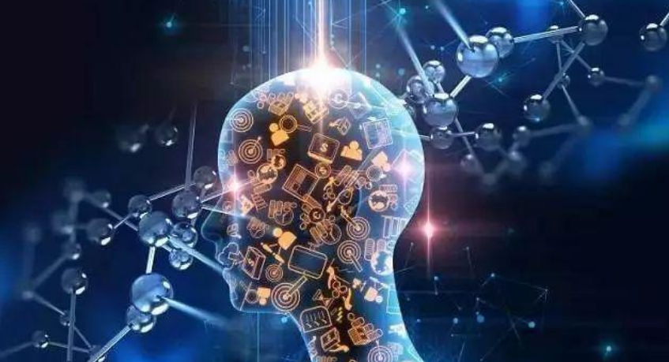

## 德国信贷风控数据建模

## （进阶3：决策树 / 神经网络 / 支持向量机）

### 策略制定及验证：张君颖 ； 报告日期：2020.11.28

本报告不构成投资建议，转载需注明作者且不得删改

作者邮箱：zhang.jun.ying@outlook.com

### 1. 决策树模型概述

决策树模型，将规则组合以树的形式展现，由根节点到每一个叶节点的路径构成了一条规则，路径上中间节点的特征对应着具体规则的条件，每个叶节点代表决策结果。决策树模型也可以理解为定义在特征空间与类空间的条件概率分布，在没有完成训练前，不能确定树的结构、节点量、规则条数，决策树一般通过递归选择最优特征，再从中选择最优切分点。

决策树的规则集合具有互斥并完备的性质，即每个实例都有且只有一条路径/规则所覆盖。因此，决策树是一种贪心算法 ，得到的树不一定是最优的，而是效果较好的次优模型。

对于分类问题，常用的特征选择指标有：

1. 信息增益（信息熵减少的值即信息增益，值越高，分类越好）
2. 信息增益比 （信息增益除以特征自身的信息熵）
3. 基尼指数 （分类纯度越高，Gin值越小）

给定特征划分后得到的信息熵的和，就是条件熵。信息增益的值小于一定阈值时，停止本次分裂。

处理分类决策树过拟合：剪枝（pruning）。预剪枝：在测试集（有对应的验证集）上，生成模型分支前后的分类误差/正确率，若新分支对预测结果有提升，则保留新分支。后剪枝：从泛化能力角度/损失函数加正则项的角度实现，采样递归的方法，从叶子节点向上一层的父节点回撤，验证回撤后的预测性能是否提升。

对于回归问题，决策树模型只需将损失函数替换为平方误差（MSE），其模型的生成过程与分类问题一致：特征选择、决策生成、剪枝，只是叶子节点的预测值以该节点下的均值作为预测结果。

**模型评估指标**  
分类问题：基尼系数（Gini在决策树中应用最广泛的是CART模型）、信息增益（entropy常用于ID3模型）等  
回归问题：均方误差（MSE）、平均绝对误差（MAE）等

其中，CART: Classification and Regression Trees

不同决策树比较：

[output not shown]

由于决策树自带分箱效果，因此，建模时对连续变量不再进行分箱，对离散变量直接采用WOE编码进行数值化。

需要注意：变量分箱是传统评分卡建模必要的步骤，可以增加模型的稳定性，但分箱后，连续变量由原始的无限种取值可能，变为有限数量的取值，这会限制决策树等复杂模型的学习能力，因为模型训练时，可选择的切分点变得非常有限。因此，机器学习时，可以不做分箱，对于离散变量，甚至可以用 one-hot 编码。

### 2. 决策树建模实战

```python
import os
import sys
import pandas as pd
import numpy as np
import warnings
warnings.filterwarnings("ignore") ##忽略警告
from sklearn.model_selection import train_test_split
import variable_encode as var_encode
import numbers
from sklearn.metrics import confusion_matrix,recall_score, auc, roc_curve,precision_score,accuracy_score
from sklearn.neural_network import MLPClassifier
from sklearn.tree import DecisionTreeClassifier
from sklearn.model_selection import GridSearchCV
from sklearn.preprocessing import StandardScaler
from sklearn.svm import LinearSVC,SVC
from sklearn.metrics import precision_recall_curve
import matplotlib.pyplot as plt
from sklearn.decomposition import PCA
import matplotlib
matplotlib.rcParams['font.sans-serif']=['SimHei']   # 用黑体显示中文
matplotlib.rcParams['axes.unicode_minus']=False     # 正常显示负号
```

```python
def data_read(data_path,file_name):
    df = pd.read_csv( os.path.join(data_path, file_name), delim_whitespace = True, header = None )
    columns = ['status_account','duration','credit_history','purpose', 'amount',
               'svaing_account', 'present_emp', 'income_rate', 'personal_status',
               'other_debtors', 'residence_info', 'property', 'age',
               'inst_plans', 'housing', 'num_credits',
               'job', 'dependents', 'telephone', 'foreign_worker', 'target']
    df.columns = columns
    # 将标签变量由状态1,2转为0,1; 其中0表示好信用，1表示坏信用
    df.target = df.target - 1
    # 将数据分为data_train（训练集）和 data_test（测试集）两部分
    # 按目标变量进行分层抽样，即训练集和测试集中，好坏样本的比例相同。
    data_train, data_test = train_test_split(df, test_size=0.2, random_state=0,stratify=df.target)
    # 由于训练集、测试集是随机划分，索引是乱的，需要重新排序
    data_train = data_train.reset_index(drop=True)
    data_test = data_test.reset_index(drop=True)
    return data_train, data_test
```

```python
## 离散变量与连续变量区分
def category_continue_separation(df,feature_names):
    categorical_var = []
    numerical_var = []
    if 'target' in feature_names:
        feature_names.remove('target')
    ##先判断类型，如果是int或float就直接作为连续变量
    numerical_var = list(df[feature_names].select_dtypes(include=['int','float','int32','float32','int64','float64']).columns.values)
    categorical_var = [x for x in feature_names if x not in numerical_var]
    return categorical_var,numerical_var
if __name__ == '__main__':
    data_path = os.path.join('C:\\Users\\lotbear\\Desktop\\Data-science！','金融风控实战数据')
    file_name = 'german.csv'
    ##读取数据
    data_train, data_test = data_read(data_path,file_name)
    sum(data_train.target ==0)
    data_train.target.sum()
    ##区分离散变量与连续变量
    feature_names = list(data_train.columns)
    feature_names.remove('target')
    categorical_var,numerical_var = category_continue_separation(data_train,feature_names)

    data_df = pd.concat([data_train,data_test],axis=0)
    data_df = data_df.reset_index(drop=True)
    x_data = data_df.loc[:,data_df.columns != 'target']
    y_data = data_df.target

print('原始数据中，好信用样本量：',sum( data_df.target == 0))
print('原始数据中，坏信用样本量：',sum( data_df.target == 1))
print('原始数据总样本量：',data_df.shape)
```

```
原始数据中，好信用样本量： 700
原始数据中，坏信用样本量： 300
原始数据总样本量： (1000, 21)
```

```python
## 离散变量直接WOE编码
var_all_bin = list(data_train.columns)
var_all_bin.remove('target')
##训练集WOE编码
df_train_woe, dict_woe_map, dict_iv_values ,var_woe_name = var_encode.woe_encode(data_train,
                                                                                 data_path,categorical_var,
                                                                                 data_train.target,'dict_woe_map', flag='train')
##测试集WOE编码
df_test_woe, var_woe_name = var_encode.woe_encode(data_test,data_path,categorical_var, data_test.target, 'dict_woe_map',flag='test')
```

```python
## 连续变量缺失值做填补
for i in numerical_var:
    if sum(data_train[i].isnull()) >0:
        data_train[i].fillna(data_train[i].mean(),inplace=True)
    if sum(data_test[i].isnull()) >0:
        data_test[i].fillna(data_test[i].mean(),inplace=True)
```

```python
## 组成分箱后的训练集与测试集
data_train.reset_index(drop=True,inplace=True)
data_test.reset_index(drop=True,inplace=True)
var_1 = numerical_var
var_1.append('target')
data_train_1 = pd.concat([df_train_woe[var_woe_name],data_train[var_1]],axis=1)
data_test_1 = pd.concat([df_test_woe[var_woe_name],data_test[var_1]],axis=1)
```

```python
## 取出训练数据与测试数据
var_all = list(data_train_1.columns)
var_all.remove('target')
## 变量归一化
scaler = StandardScaler().fit(data_train_1[var_all])
data_train_1[var_all] = scaler.transform(data_train_1[var_all])
data_test_1[var_all] = scaler.transform(data_test_1[var_all])
```

```python
x_train = np.array(data_train_1[var_all])
y_train = np.array(data_train_1.target)
x_test = np.array(data_test_1[var_all])
y_test = np.array(data_test_1.target)
```

```python
## 决策树模型
## 设置待优化的超参数
DT_param = {'max_depth': np.arange(2,10,1),
            'class_weight': [{1: 1, 0: 1}, {1: 2, 0: 1}, {1: 3, 0: 1}]  }
## 初始化网格搜索
DT_gsearch = GridSearchCV(
        estimator=DecisionTreeClassifier(),
        param_grid=DT_param, cv=3, scoring='f1', n_jobs=-1, verbose=2)
## 执行超参数优化
DT_gsearch.fit(x_train, y_train)
print('决策树模型最优得分 {0},\n最优参数{1}'.format(DT_gsearch.best_score_,DT_gsearch.best_params_))
```

```
Fitting 3 folds for each of 24 candidates, totalling 72 fits
```

```
[Parallel(n_jobs=-1)]: Using backend LokyBackend with 8 concurrent workers.
[Parallel(n_jobs=-1)]: Done  25 tasks      | elapsed:    8.0s
```

```
决策树模型最优得分 0.576016418037632,
最优参数{'class_weight': {1: 3, 0: 1}, 'max_depth': 5}
```

```
[Parallel(n_jobs=-1)]: Done  72 out of  72 | elapsed:    9.1s finished
```

```python
## 用最优参数，初始化决策树模型
DT_model_1 = DecisionTreeClassifier(max_depth = DT_gsearch.best_params_['max_depth'],
                                    class_weight=DT_gsearch.best_params_['class_weight'])
## 训练决策树模型
DT_model_fit = DT_model_1.fit(x_train, y_train)
## 属性
#    DT_model_fit.feature_importances_
#    DT_model_fit.max_features_
#    DT_model_fit.n_outputs_
```

```python
## 模型预测
y_pred = DT_model_fit.predict(x_test)
y_score_test = DT_model_fit.predict_proba(x_test)[:, 1]

## 画出决策树
from graphviz import Source
from sklearn.tree import export_graphviz

PROJECT_ROOT_DIR = "."
CHAPTER_ID = "decision_trees"
# 当前路径下新建文件夹‘images’，文件夹里再新建文件夹（章节ID），整体作为图像路径
IMAGES_PATH = os.path.join(PROJECT_ROOT_DIR, "images", CHAPTER_ID)
os.makedirs(IMAGES_PATH, exist_ok=True)

export_graphviz(
        DT_model_fit, # 方法
        out_file=os.path.join(IMAGES_PATH, "Credit_tree.dot"), # 输出决策树文档，为制图做准备
        feature_names=var_all,
        class_names=['Bad_credit','Good_credit'],
        rounded=True,
        filled=True
    )
# 将输出的dot文档打开并绘图
print('***绘制20个特征分类下的决策树***')
print('='*80)
print('第一行：特征名称+数值条件')
print('第二行：gini基尼系数，数值越小分类纯度越高')
print('第三行：sample该节点下的样本总量')
print('第四行：预测的坏样本、好样本的分布情况')
print('第五行：分类名称，正样本为坏信用（target=1），负样本为好信用（target=0）')
print('='*80)
Source.from_file(os.path.join(IMAGES_PATH, "Credit_tree.dot"))
```

[output not shown]

[figure not shown]

```python
# 保存决策树图片
graph = Source.from_file(os.path.join(IMAGES_PATH, "Credit_tree.dot"))
graph.render('images/decision_trees/DT_classification_plot', format='png')
```

```
'images/decision_trees\\DT_classification_plot.png'
```

```python
## 计算混淆矩阵与recall、precision
cnf_matrix = pd.DataFrame(data=confusion_matrix(y_test, y_pred),
                          columns=['预测结果为正例','预测结果为反例'],index=['真实样本为正例','真实样本为反例'])
recall_value = recall_score(y_test, y_pred)
precision_value = precision_score(y_test, y_pred)
acc = accuracy_score(y_test, y_pred)
print('DT 决策树模型的召回率：',recall_value)
print('DT 决策树模型的精准率：',precision_value)
print('DT 决策树模型预测的正确率:',acc)
print('='*80)
print('测试集的混淆矩阵：')
cnf_matrix
```

```
DT 决策树模型的召回率： 0.7333333333333333
DT 决策树模型的精准率： 0.41904761904761906
DT 决策树模型预测的正确率: 0.615
================================================================================
测试集的混淆矩阵：
```

|  | 预测结果为正例 | 预测结果为反例 |
| --- | --- | --- |
| 真实样本为正例 | 79 | 61 |
| 真实样本为反例 | 16 | 44 |

```python
## 计算fpr与tpr
fpr, tpr, thresholds = roc_curve(y_test, y_score_test)

## 计算AR、gini等
roc_auc = auc(fpr, tpr)
ks = max(tpr - fpr)
ar = 2*roc_auc-1
gini = ar
print('测试集的 AR/基尼系数为:',ar)
print('测试集的KS值为:',ks)
print('测试集的AUC值为:',roc_auc)
```

```
测试集的 AR/基尼系数为: 0.3555952380952381
测试集的KS值为: 0.3666666666666667
测试集的AUC值为: 0.677797619047619
```

```
最大KS值: 0.3666666666666667
```

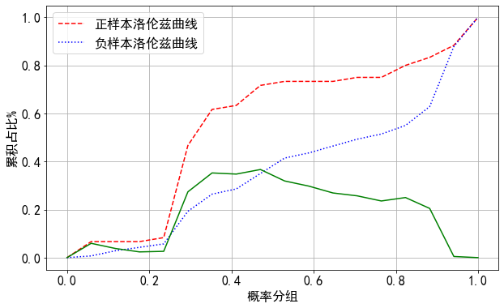

```python
## ks曲线
plt.figure(figsize=(10,6))
plt.plot(np.linspace(0,1,len(tpr)),tpr,'--',color='red', label='正样本洛伦兹曲线')
plt.plot(np.linspace(0,1,len(tpr)),fpr,':',color='blue', label='负样本洛伦兹曲线')
plt.plot(np.linspace(0,1,len(tpr)),tpr - fpr,'-',color='green')
plt.grid()
plt.xticks( fontsize=16)
plt.yticks( fontsize=16)
plt.xlabel('概率分组',fontsize=16)
plt.ylabel('累积占比%',fontsize=16)
plt.legend(fontsize=16)
print('最大KS值:',max(tpr - fpr))
```

### 3. 神经网络模型概述

上文提到的决策树，是一种通过 if-then 的方式描述非常复杂的规则集合，而神经网络模型可以通过权重调整的方式，对任意复杂的函数以任何精度拟合。权重W的个数与样本维度相等，即每个样本通过神经元模型后的输出结果都是与权重相乘再与阈值相加后通过激活函数得到。

以多层前馈网络为例;

第一层为输入层，没有激活函数，只是将输入信号传递给隐层的神经元；

中间层称为隐层，有激活函数，隐层中的每一层的每一个神经元都与前一层的所有神经元构成一个感知器模型（也是logistic 回归模型）；

最后一层为输出层，有激活函数，负责将中间层的结果加权，实现不同的逻辑运算并得到最后的预测结果。

#### 误差反向传播算法（error BackPropagation，BP）

BP 神经网络学习策略中最著名的算法代表，采用梯度下降的方式，通过迭代逐步更新权重。

梯度下降，要求函数指标具有可导性。以二分类为例，起初的感知器模型的激活函数是 sign 符号函数 ，其导数性质不好，不易优化，将其改进为 sigmoid 函数，一个关于自身的函数。支持向量机 SVM 模型中采用 hinge 合页损失函数损失代替 0-1 损失，神经网络模型采用交叉熵损失代替 0-1 损失，这与 logistic 回归模型的损失函数一致。

大部分算法要求损失函数至少是一阶可导的，而 Xgboost 模型则要求损失函数二阶导数也存在。交叉熵损失函数是从概率分布角度衡量预测值的分布与真实值分布之间的差异，交叉熵越小，两个分布越相似，预测精度越高。

以单层前馈网络的信号传输方式为例：

输入层第 i 个节点与隐藏层第 h 个节点的连接权重表示为$ν_{ih}$ ；隐层第 h 个节点的偏置项（阈值）表示为 $γ_{h} $；隐层第 h 个节点与输出层节点的连接权重为$ w_{h} $；偏置项为 θ。

则，隐层第 h 个节点的输入表达式为 : $$ α_{h}= \sum_{i=1}^dν_{ih}x_{i} $$
该节点的输出层表达式为 : $$β = \sum_{i=1}^qw_{h}b_{h} $$
其中，b<sub>h</sub> 为隐层第 h 个节点的输出 : $$ b_{h} = sigmoid ( α_{h} + γ_{h})$$

BP 算法基于梯度下降（Gradient descent）策略，以损失函数的负梯度方向对参数进行更新调整，任意参数 θ 的更新公式： θ $\longleftarrow$ θ+ $\Delta$θ

模型 权重/参数 更新路径：

a) $ w_{h} $ 先作用在输出节点的输入端 β，后作用在输出节点的预测结果 $y_{k}$；最后作用在损失函数 $L_{k}$上，其中 k 表示第 k 个样本，然后用求导的链式法则，求出 $\Delta w_{h}$ 和 $\Delta θ_{h}$ ；

b) 计算 $ν_{ih}$ 和 $γ_{h} $ 的更新值：在网格结构中，$ν_{ih}$ 先作用在第 h 个隐层节点的输入 $ α_{h}$，再作用在第 h 个隐层节点的输出 $b_{h}$ 上，然后作用在输出节点的输入β上，之后作用在输出节点的输出预测 $y_{k}$上，最后作用在损失函数 $L_{k}$上。根据求导的链式算法，可以求出$ν_{ih}$ 和 $γ_{h} $ 的更新值。

常用的防止过拟合方法：

1. 添加正则项：限制权重不要太大，倾向于选择权重均衡的参数组合；
2. 早停策略（early stopping）:当模型的性能不再提升，或趋于稳定后，即可停止训练；
3. dropout 策略：在训练过程中，随机令一部分隐层节点处于非激活状态，人为随机降低网络的复杂度，这种做法和集成学习中，添加扰动的方式类似。

### 4. 神经网络建模实战

```python
## 神经网络模型，网络初始化
nn_model = MLPClassifier(hidden_layer_sizes=(50,50),
                            activation='relu',max_iter=300,alpha=0.01)
## 神经网络模型训练
nn_model_fit = nn_model.fit(x_train, y_train)
```

```python
## 模型预测
y_pred = nn_model_fit.predict(x_test)
y_score_test = nn_model_fit.predict_proba(x_test)[:, 1]
## 计算混淆矩阵与recall、precision
cnf_matrix = pd.DataFrame(data=confusion_matrix(y_test, y_pred),
                          columns=['预测结果为正例','预测结果为反例'],index=['真实样本为正例','真实样本为反例'])
recall_value = recall_score(y_test, y_pred)
precision_value = precision_score(y_test, y_pred)
acc = accuracy_score(y_test, y_pred)
print('MLP 神经网络模型的召回率：',recall_value)
print('MLP 神经网络模型的精准率：',precision_value)
print('MLP 神经网络模型预测的正确率:',acc)
print('='*80)
print('测试集的混淆矩阵：')
cnf_matrix
```

```
MLP 神经网络模型的召回率： 0.55
MLP 神经网络模型的精准率： 0.5789473684210527
MLP 神经网络模型预测的正确率: 0.745
================================================================================
测试集的混淆矩阵：
```

|  | 预测结果为正例 | 预测结果为反例 |
| --- | --- | --- |
| 真实样本为正例 | 116 | 24 |
| 真实样本为反例 | 27 | 33 |

```python
## 计算fpr与tpr
fpr, tpr, thresholds = roc_curve(y_test, y_score_test)

## 计算AR、gini等
roc_auc = auc(fpr, tpr)
ks = max(tpr - fpr)
ar = 2*roc_auc-1
gini = ar
print('测试集的 AR/基尼系数为:',ar)
print('测试集的KS值为:',ks)
print('测试集的AUC值为:',roc_auc)
```

```
测试集的 AR/基尼系数为: 0.46690476190476193
测试集的KS值为: 0.4095238095238095
测试集的AUC值为: 0.733452380952381
```

```
最大KS值: 0.4095238095238095
```

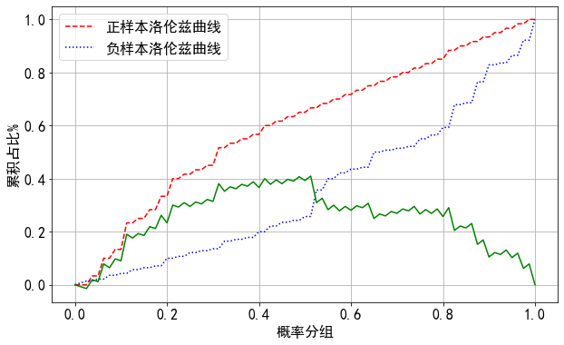

```python
## ks曲线
plt.figure(figsize=(10,6))
plt.plot(np.linspace(0,1,len(tpr)),tpr,'--',color='red', label='正样本洛伦兹曲线')
plt.plot(np.linspace(0,1,len(tpr)),fpr,':',color='blue', label='负样本洛伦兹曲线')
plt.plot(np.linspace(0,1,len(tpr)),tpr - fpr,'-',color='green')
plt.grid()
plt.xticks( fontsize=16)
plt.yticks( fontsize=16)
plt.xlabel('概率分组',fontsize=16)
plt.ylabel('累积占比%',fontsize=16)
plt.legend(fontsize=16)
print('最大KS值:',max(tpr - fpr))
```

### 5. 支持向量机模型（SVM）

支持向量机模型由简单到复杂分为三种：

1. 线性可分支持向量机（Linear Support Vector Machine in Linearly Separable Case）,样本是线性可分的，对应的最大间隔类型为硬性间隔最大化，即超平面要严格满足每个样本都分类正确；
2. 线性支持向量机（Linear Support Vector machine）,当样本近似线性可分，引入松弛因子，战略性放弃噪声数据；
3. 非线性支持向量机（Non-Linear Support Vector machine），当样本非线性可分，采用核 kernel 技术进行数据映射，在高维空间采用软间隔最大化的方法，得到一个非线性模型。

支持向量机和神经网络模型，都是从感知器模型发展、改进而来。在感知器模型中，激活函数 y = ƒ(W<sup>T</sup>x+b)

以二分类感知器为例，当 W<sup>T</sup>x+b$\geq$0 ，输出 y = +1；当 W<sup>T</sup>x+b$\leq$0 ，输出 y = -1。由此可知，样本被错误分类时，y(W<sup>T</sup>x+b)<0，将该函数作为损失函数，对权重 W 和偏置项 b 分别求偏导，然后采用梯度下降法逐步迭代，减小损失函数值，增强模型分类的正确率。

在感知器分类迭代过程：找出上一轮被错误分类的样本，调整超平面，并向这些分类错误的样本靠近，直到这些样本都被正确分类为止。

由于感知器对于非线性问题无能为力，神经网络在感知器基础上，通过改变激活函数、增加感知器个数、层数，在原空间解决非线性问题；而支持向量机则借助核 kernel 函数，将低维空间的非线性问题转换为高维空间的线性可分问题。

### 6. 支持向量机（SVM）建模实战

#### 线性支持向量机模型

```python
## 设置待优化的超参数
lin_svm_param = {'C': np.arange(0.1,5,0.1),
                'class_weight': [{1: 1, 0: 1}, {1: 2, 0: 1}, {1: 3, 0: 1}]  }
## 初始化网格搜索
lin_svm_gsearch = GridSearchCV(estimator=LinearSVC(),param_grid=lin_svm_param,
                  cv=3, scoring='roc_auc', n_jobs=-1, verbose=2)
## 执行超参数优化
lin_svm_gsearch.fit(x_train, y_train)
print('线性SVM模型最优得分 {0},\n最优参数{1}'.format(lin_svm_gsearch.best_score_,lin_svm_gsearch.best_params_))

## 用最优参数，初始化模型
lin_svm_model = LinearSVC(C = lin_svm_gsearch.best_params_['C'],
                                    class_weight=lin_svm_gsearch.best_params_['class_weight'])
## 模型训练
lin_svm_model_fit = lin_svm_model.fit(x_train, y_train)
```

```
Fitting 3 folds for each of 147 candidates, totalling 441 fits
```

```
[Parallel(n_jobs=-1)]: Using backend LokyBackend with 8 concurrent workers.
[Parallel(n_jobs=-1)]: Done  34 tasks      | elapsed:    2.0s
[Parallel(n_jobs=-1)]: Done 194 tasks      | elapsed:   11.7s
[Parallel(n_jobs=-1)]: Done 397 tasks      | elapsed:   25.3s
[Parallel(n_jobs=-1)]: Done 441 out of 441 | elapsed:   28.3s finished
```

```
线性SVM模型最优得分 0.8122800586510263,
最优参数{'C': 4.8, 'class_weight': {1: 2, 0: 1}}
```

```python
## 模型预测
y_pred = lin_svm_model_fit.predict(x_test)
## 计算混淆矩阵与recall、precision
cnf_matrix = pd.DataFrame(data=confusion_matrix(y_test, y_pred),
                          columns=['预测结果为正例','预测结果为反例'],index=['真实样本为正例','真实样本为反例'])
recall_value = recall_score(y_test, y_pred)
precision_value = precision_score(y_test, y_pred)
acc = accuracy_score(y_test, y_pred)
print('Linear_SVM 模型的召回率：',recall_value)
print('Linear_SVM 模型的精准率：',precision_value)
print('Linear_SVM 模型预测的正确率:',acc)
print('='*80)
print('测试集的混淆矩阵：')
cnf_matrix
```

```
Linear_SVM 模型的召回率： 0.7
Linear_SVM 模型的精准率： 0.5384615384615384
Linear_SVM 模型预测的正确率: 0.73
================================================================================
测试集的混淆矩阵：
```

|  | 预测结果为正例 | 预测结果为反例 |
| --- | --- | --- |
| 真实样本为正例 | 104 | 36 |
| 真实样本为反例 | 18 | 42 |

#### 非线性支持向量机模型

```python
## 设置待优化的超参数
svm_param = {'C': np.arange(0.1,5,0.1),
                'gamma':np.arange(0.01,10,1),
                'class_weight': [{1: 1, 0: 1}, {1: 2, 0: 1}, {1: 3, 0: 1}]  }
## 初始化网格搜索
svm_gsearch = GridSearchCV(estimator=SVC(kernel='rbf'),param_grid=svm_param,
                  cv=3, scoring='roc_auc', n_jobs=-1, verbose=2)
## 执行超参数优化
svm_gsearch.fit(x_train, y_train)
print('非线性SVM模型最优得分 {0},\n最优参数{1}'.format(svm_gsearch.best_score_,svm_gsearch.best_params_))
```

```
Fitting 3 folds for each of 1470 candidates, totalling 4410 fits
```

```
[Parallel(n_jobs=-1)]: Using backend LokyBackend with 8 concurrent workers.
[Parallel(n_jobs=-1)]: Done  34 tasks      | elapsed:    2.2s
[Parallel(n_jobs=-1)]: Done 210 tasks      | elapsed:   10.1s
[Parallel(n_jobs=-1)]: Done 540 tasks      | elapsed:   18.8s
[Parallel(n_jobs=-1)]: Done 1168 tasks      | elapsed:   37.8s
[Parallel(n_jobs=-1)]: Done 1578 tasks      | elapsed:   52.6s
[Parallel(n_jobs=-1)]: Done 2258 tasks      | elapsed:  1.1min
[Parallel(n_jobs=-1)]: Done 3018 tasks      | elapsed:  1.4min
[Parallel(n_jobs=-1)]: Done 3696 tasks      | elapsed:  1.9min
[Parallel(n_jobs=-1)]: Done 4385 tasks      | elapsed:  2.4min
```

```
非线性SVM模型最优得分 0.8176153134763192,
最优参数{'C': 1.9000000000000001, 'class_weight': {1: 2, 0: 1}, 'gamma': 0.01}
```

```
[Parallel(n_jobs=-1)]: Done 4410 out of 4410 | elapsed:  2.4min finished
```

```python
## 用最优参数，初始化模型
svm_model = SVC(kernel='rbf',C =svm_gsearch.best_params_['C'],gamma=svm_gsearch.best_params_['gamma'],
                                class_weight=svm_gsearch.best_params_['class_weight'],probability=True)
## 模型训练
svm_model_fit = svm_model.fit(x_train, y_train)
```

```python
## 模型预测
y_pred = svm_model_fit.predict(x_test)
y_score_test = svm_model_fit.predict_proba(x_test)[:, 1]
## 计算混淆矩阵与recall、precision
cnf_matrix = pd.DataFrame(data=confusion_matrix(y_test, y_pred),
                          columns=['预测结果为正例','预测结果为反例'],index=['真实样本为正例','真实样本为反例'])
recall_value = recall_score(y_test, y_pred)
precision_value = precision_score(y_test, y_pred)
acc = accuracy_score(y_test, y_pred)
print('非线性 SVM 模型的召回率：',recall_value)
print('非线性 SVM 模型的精准率：',precision_value)
print('非线性 SVM 模型预测的正确率:',acc)
print('='*80)
print('测试集的混淆矩阵：')
cnf_matrix
```

```
非线性 SVM 模型的召回率： 0.6833333333333333
非线性 SVM 模型的精准率： 0.5256410256410257
非线性 SVM 模型预测的正确率: 0.72
================================================================================
测试集的混淆矩阵：
```

|  | 预测结果为正例 | 预测结果为反例 |
| --- | --- | --- |
| 真实样本为正例 | 103 | 37 |
| 真实样本为反例 | 19 | 41 |

```python
## 计算fpr与tpr
fpr, tpr, thresholds = roc_curve(y_test, y_score_test)

## 计算AR、gini等
roc_auc = auc(fpr, tpr)
ks = max(tpr - fpr)
ar = 2*roc_auc-1
gini = ar
print('测试集的 AR/基尼系数为:',ar)
print('测试集的KS值为:',ks)
print('测试集的AUC值为:',roc_auc)
```

```
测试集的 AR/基尼系数为: 0.5533333333333335
测试集的KS值为: 0.4785714285714286
测试集的AUC值为: 0.7766666666666667
```

```
最大KS值: 0.4785714285714286
```

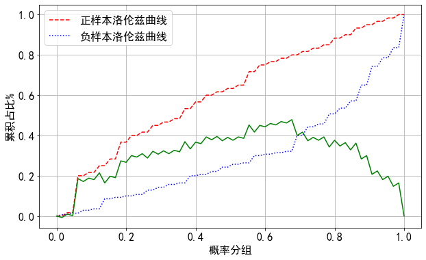

```python
## ks曲线
plt.figure(figsize=(10,6))
plt.plot(np.linspace(0,1,len(tpr)),tpr,'--',color='red', label='正样本洛伦兹曲线')
plt.plot(np.linspace(0,1,len(tpr)),fpr,':',color='blue', label='负样本洛伦兹曲线')
plt.plot(np.linspace(0,1,len(tpr)),tpr - fpr,'-',color='green')
plt.grid()
plt.xticks( fontsize=16)
plt.yticks( fontsize=16)
plt.xlabel('概率分组',fontsize=16)
plt.ylabel('累积占比%',fontsize=16)
plt.legend(fontsize=16)
print('最大KS值:',max(tpr - fpr))
```

#### 尝试绘制 SVM 在 二维空间的决策边界

为了能可视化 SVM 分类边界，我们先将 20 维变量，通过 PCA 主成分分析法降维至 2 维数据，然后用 SVM 的核函数映射到高维空间，进行超平面切割。

PCA 主成分分析降维法，相当于将‘高维数据’以尽可能多地保留特征形态的方式，压缩至‘低维数据’。

```python
CHAPTER_ID = "svm"

# PCA降维，20维变量降到2维
model_pca = PCA(n_components=2).fit(x_train)
X_pca = model_pca.transform(x_test)

# 2维数据使用 SVM 升至 高维进行超平面分类
SVM_2D = SVC(kernel='rbf',C=1E6)
SVM_2D_model = SVM_2D.fit(X_pca,y_test)

# 模型预测
y_pred = SVM_2D_model.predict(X_pca)
```

```python
## 计算混淆矩阵与recall、precision
cnf_matrix = pd.DataFrame(data=confusion_matrix(y_test, y_pred),
                          columns=['预测结果为正例','预测结果为反例'],index=['真实样本为正例','真实样本为反例'])
recall_value = recall_score(y_test, y_pred)
precision_value = precision_score(y_test, y_pred)
acc = accuracy_score(y_test, y_pred)
print('SVM_2D 模型的召回率：',recall_value)
print('SVM_2D 模型的精准率：',precision_value)
print('SVM_2D 模型预测的正确率:',acc)
print('='*80)
print('测试集的混淆矩阵：')
cnf_matrix
```

```
SVM_2D 模型的召回率： 0.6333333333333333
SVM_2D 模型的精准率： 0.8444444444444444
SVM_2D 模型预测的正确率: 0.855
================================================================================
测试集的混淆矩阵：
```

|  | 预测结果为正例 | 预测结果为反例 |
| --- | --- | --- |
| 真实样本为正例 | 133 | 7 |
| 真实样本为反例 | 22 | 38 |

```python
# 当前路径下新建文件夹‘images’，文件夹里再新建文件夹（图片类目），整体作为图像路径
IMAGES_PATH = os.path.join(".", "images", "SVM_model" )
os.makedirs(IMAGES_PATH, exist_ok=True)
# 定义存储图片函数，也可以保存成pdf图像
def save_fig(fig_id, tight_layout=True, fig_extension="png", resolution=300):
    path = os.path.join(IMAGES_PATH, fig_id + "." + fig_extension)
    print("Saving figure", fig_id)
    if tight_layout:
        plt.tight_layout()
    plt.savefig(path, format=fig_extension, dpi=resolution)
```

```
Saving figure SVM_classification_plot
```

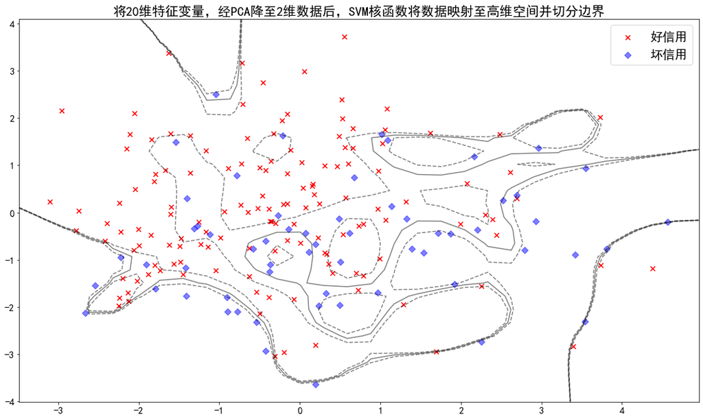

```python
# 制图
plt.figure(figsize=(15,9))

# 原始数据降维至 2D，绘制散点图
index_1 = y_test ==0 # 以 bool 数值为索引，判断 target = 0 是否为真
plt.scatter(X_pca[index_1, 0], X_pca[index_1, 1], c='red',marker='x',label='好信用',s=50)
plt.scatter(X_pca[~index_1, 0], X_pca[~index_1, 1], c='blue',marker='D',alpha=0.5,label='坏信用',s=50)
plt.title('将20维特征变量，经PCA降至2维数据后，SVM核函数将数据映射至高维空间并切分边界',fontsize=20)
plt.xticks( fontsize=15)
plt.yticks( fontsize=15)
plt.legend(fontsize=19)

# 函数定义 SVM 决策边界的绘制
def plot_svc_decision_function(model, ax=None, plot_support=True):
    """Plot the decision function for a 2D SVC"""
    if ax is None:
        ax = plt.gca()
    xlim = ax.get_xlim()
    ylim = ax.get_ylim()

    # create grid to evaluate model
    x = np.linspace(xlim[0], xlim[1], 30)
    y = np.linspace(ylim[0], ylim[1], 30)
    Y, X = np.meshgrid(y, x)
    xy = np.vstack([X.ravel(), Y.ravel()]).T
    P = model.decision_function(xy).reshape(X.shape)

    # plot decision boundary and margins
    ax.contour(X, Y, P, colors='k',
               levels=[-1, 0, 1], alpha=0.5,
               linestyles=['--', '-', '--'])

    # plot support vectors
    if plot_support:
        ax.scatter(model.support_vectors_[:, 0],
                   model.support_vectors_[:, 1],
                   s=300, linewidth=1, facecolors='none');
    ax.set_xlim(xlim)
    ax.set_ylim(ylim)

plot_svc_decision_function(SVM_2D_model)
save_fig("SVM_classification_plot")
plt.show()
```

```python
# def plot_svc_decision_boundary(svm_clf, xmin, xmax):
#    """针对 Linear-SVM 绘图，非线性 SVM 无 coef 属性"""
#     w = svm_clf.coef_[0] # 分割线系数
#     b = svm_clf.intercept_[0] # 分割线截距
#
#     # At the decision boundary, w0*x0 + w1*x1 + b = 0
#     # => x1 = -w0/w1 * x0 - b/w1
#     x0 = np.linspace(xmin, xmax, 200)
#     decision_boundary = -w[0]/w[1] * x0 - b/w[1]
#
#     margin = 1/w[1]
#     gutter_up = decision_boundary + margin
#     gutter_down = decision_boundary - margin
#
#     # svs = svm_clf.support_vectors_
#     # plt.scatter(svs[:, 0], svs[:, 1], s=180, facecolors='#FFAAAA')
#     plt.plot(x0, decision_boundary, "k-", linewidth=2)
#     plt.plot(x0, gutter_up, "k--", linewidth=2)
#     plt.plot(x0, gutter_down, "k--", linewidth=2)
#
# plot_svc_decision_boundary(lin_svm_model_fit, 0, 1.5) # （model，最小值，最大值）
# plt.plot(X_pca[:, 0][y_pred==0], X_pca[:, 1][y_pred==0], "yo")
# plt.plot(X_pca[:, 0][y_pred==1], X_pca[:, 1][y_pred==1], "bs") # 效果与 scatter 点集相同
```